# Assignment-4

#### EX. 10.12. B

Observations 65, 61, 53, 8, and 3 are outliers as they exceed the leverage value h=2p/n= 1/8= .125.

```r
## hat matrix building
X_0 <- data.frame(Rental.1[,c(2:5)])
X <- data.matrix(X_0,rownames.force = NA)

t(X)
```

[output not shown]

```r
 solve(t(X) %*% X)
```

```
##               X.1           X.2           X.3           X.4
## X.1  3.520616e-04 -2.390359e-04  2.848496e-03 -4.164756e-09
## X.2 -2.390359e-04  6.487240e-04 -2.456135e-03 -1.871892e-08
## X.3  2.848496e-03 -2.456135e-03  6.704030e-01 -2.547278e-07
## X.4 -4.164756e-09 -1.871892e-08 -2.547278e-07  1.424560e-12
```

```r
 X_n <- matrix( c( 10, 12, 0.05, 350000),  byrow=F )

 H_nn <- t(X_n) %*% solve(t(X) %*% X) %*% X_n

 H_nn
```

```
##            [,1]
## [1,] 0.05203178
```

#### EX. 10.12. C

The H_nn valuse gained was 0.05203 which is well within the range of the h leverage values for the data, we can conclude no hidden extrapolation is involved.

```r
## Getting  COOK's, DFFITS and DFBETAS values.

influence.measures(fit)
```

```
## Influence measures of
##   lm(formula = Y ~ ., data = Rental.1) :
##
##       dfb.1_   dfb.X.1   dfb.X.2   dfb.X.3   dfb.X.4    dffit cov.r   cook.d
## 1  -0.214178  0.056544  0.183868  0.056692 -0.075745 -0.24190 1.074 1.17e-02
## 2   0.017968 -0.255553  0.000829 -0.273144  0.160603 -0.39501 1.016 3.08e-02
## 3  -0.231786 -0.155328  0.236414  0.100780 -0.011494 -0.28428 1.299 1.63e-02
## 4   0.004038  0.007926 -0.014068 -0.002603  0.015599 -0.02403 1.111 1.17e-04
## 5   0.010977  0.024916 -0.000118  0.006442 -0.031709  0.04982 1.097 5.02e-04
## 6   0.195115 -0.564852 -0.176722 -0.617191  0.448173 -0.87355 0.638 1.37e-01
## 7  -0.012779  0.021324 -0.021073 -0.047729  0.062905 -0.10250 1.100 2.12e-03
## 8  -0.014210 -0.007198  0.003014  0.095519  0.012599  0.11641 1.334 2.74e-03
## 9   0.502106 -0.229449 -0.454849 -0.398095  0.402342  0.62837 0.945 7.64e-02
## 10 -0.003040 -0.004761  0.004340 -0.003401  0.006895  0.01569 1.098 4.99e-05
## 11 -0.004099 -0.000163  0.004020  0.001612  0.000441  0.00555 1.144 6.25e-06
```

[output cut: 152 more lines]

```r
influence.measures(fit)$is.inf
```

```
##    dfb.1_ dfb.X.1 dfb.X.2 dfb.X.3 dfb.X.4 dffit cov.r cook.d   hat
## 1   FALSE   FALSE   FALSE   FALSE   FALSE FALSE FALSE  FALSE FALSE
## 2   FALSE   FALSE   FALSE   FALSE   FALSE FALSE FALSE  FALSE FALSE
## 3   FALSE   FALSE   FALSE   FALSE   FALSE FALSE  TRUE  FALSE  TRUE
## 4   FALSE   FALSE   FALSE   FALSE   FALSE FALSE FALSE  FALSE FALSE
## 5   FALSE   FALSE   FALSE   FALSE   FALSE FALSE FALSE  FALSE FALSE
## 6   FALSE   FALSE   FALSE   FALSE   FALSE  TRUE  TRUE  FALSE FALSE
## 7   FALSE   FALSE   FALSE   FALSE   FALSE FALSE FALSE  FALSE FALSE
## 8   FALSE   FALSE   FALSE   FALSE   FALSE FALSE  TRUE  FALSE  TRUE
## 9   FALSE   FALSE   FALSE   FALSE   FALSE FALSE FALSE  FALSE FALSE
## 10  FALSE   FALSE   FALSE   FALSE   FALSE FALSE FALSE  FALSE FALSE
## 11  FALSE   FALSE   FALSE   FALSE   FALSE FALSE FALSE  FALSE FALSE
## 12  FALSE   FALSE   FALSE   FALSE   FALSE FALSE FALSE  FALSE FALSE
## 13  FALSE   FALSE   FALSE   FALSE   FALSE FALSE FALSE  FALSE FALSE
## 14  FALSE   FALSE   FALSE   FALSE   FALSE FALSE FALSE  FALSE FALSE
```

[output cut: 67 more lines]

#### Ans. D.

According to COOK, DFFITS and DFBETAS value obseravtion 6 shows influence by DFFITS criterion. Other observations seem OK.

```r
## Calculating the average absolute percent difference.

fit <- lm(Y ~ ., data = Rental.1)

data.new1 <-  Rental.1[-c(3), ]

data.new1
```

```
## # A tibble: 80 × 5
##        Y   X.1   X.2   X.3    X.4
##    <dbl> <dbl> <dbl> <dbl>  <dbl>
##  1  13.5     1  5.02  0.14 123000
##  2  12      14  8.19  0.27 104079
##  3  15       4 10.7   0.05  57112
##  4  14      11  8.97  0.07  60000
##  5  10.5    15  9.45  0.24 101385
##  6  14       2  8     0.19  31300
##  7  16.5     1  6.62  0.6  248172
##  8  17.5     1  6.2   0    215000
##  9  16.5     8 11.8   0.03 251015
## 10  17      12 14.6   0.08 291264
## # … with 70 more rows
```

```r
model.2 <- lm(Y ~ ., data = data.new1)

Dif <- mean(abs((fitted(model.2)-fitted(fit))/fitted(fit))*100)/80
Dif
```

```
## [1] 0.09021193
```

##### The observation 3 only shows a .09% difference and that is not influential.

```r
data.new2 <-  Rental.1[-c(8), ]

data.new2
```

```
## # A tibble: 80 × 5
##        Y   X.1   X.2   X.3    X.4
##    <dbl> <dbl> <dbl> <dbl>  <dbl>
##  1  13.5     1  5.02  0.14 123000
##  2  12      14  8.19  0.27 104079
##  3  10.5    16  3     0     39998
##  4  15       4 10.7   0.05  57112
##  5  14      11  8.97  0.07  60000
##  6  10.5    15  9.45  0.24 101385
##  7  14       2  8     0.19  31300
##  8  17.5     1  6.2   0    215000
##  9  16.5     8 11.8   0.03 251015
## 10  17      12 14.6   0.08 291264
## # … with 70 more rows
```

```r
model.3 <- lm(Y ~ ., data = data.new2)

Dif.2 <- mean(abs((fitted(model.3)-fitted(fit))/fitted(fit))*100)/80
Dif.2
```

```
## [1] 0.08068625
```

##### The observation 8 only shows a .08% difference and that is not influential.

```r
data.new3 <-  Rental.1[-c(53), ]

data.new3
```

```
## # A tibble: 80 × 5
##        Y   X.1   X.2   X.3    X.4
##    <dbl> <dbl> <dbl> <dbl>  <dbl>
##  1  13.5     1  5.02  0.14 123000
##  2  12      14  8.19  0.27 104079
##  3  10.5    16  3     0     39998
##  4  15       4 10.7   0.05  57112
##  5  14      11  8.97  0.07  60000
##  6  10.5    15  9.45  0.24 101385
##  7  14       2  8     0.19  31300
##  8  16.5     1  6.62  0.6  248172
##  9  17.5     1  6.2   0    215000
## 10  16.5     8 11.8   0.03 251015
## # … with 70 more rows
```

```r
model.4 <- lm(Y ~ ., data = data.new3)

Dif.3 <- mean(abs((fitted(model.4)-fitted(fit))/fitted(fit))*100)/80
Dif.3
```

```
## [1] 0.03893318
```

##### The observation 53 only shows a .04% difference and that is not influential.

```r
data.new4 <-  Rental.1[-c(61), ]

data.new4
```

```
## # A tibble: 80 × 5
##        Y   X.1   X.2   X.3    X.4
##    <dbl> <dbl> <dbl> <dbl>  <dbl>
##  1  13.5     1  5.02  0.14 123000
##  2  12      14  8.19  0.27 104079
##  3  10.5    16  3     0     39998
##  4  15       4 10.7   0.05  57112
##  5  14      11  8.97  0.07  60000
##  6  10.5    15  9.45  0.24 101385
##  7  14       2  8     0.19  31300
##  8  16.5     1  6.62  0.6  248172
##  9  17.5     1  6.2   0    215000
## 10  16.5     8 11.8   0.03 251015
## # … with 70 more rows
```

```r
model.5 <- lm(Y ~ ., data = data.new4)

Dif.4 <- mean(abs((fitted(model.5)-fitted(fit))/fitted(fit))*100)/80
Dif.4
```

```
## [1] 0.0343638
```

##### The observation 61 only shows a .03% difference and that is not influential.

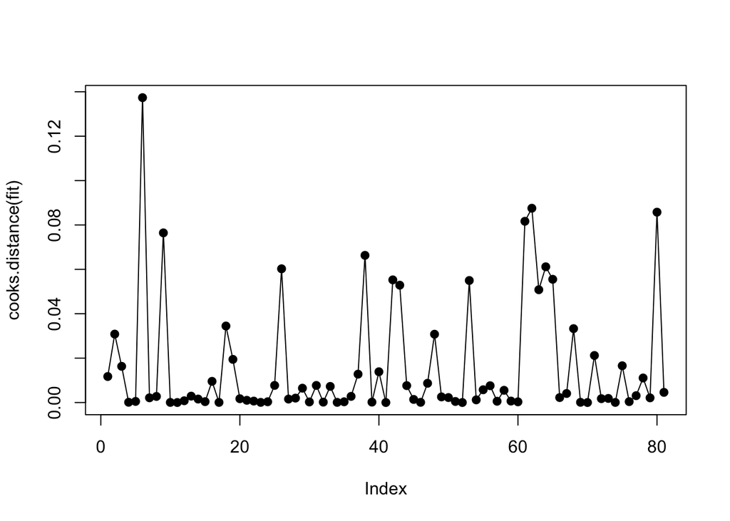

```r
## Plotting Cook's Distance

plot( cooks.distance(fit), type='o',
pch=19 )
```

#### EX. 10.12.F.

Cook’s values for all plots were calculated see line. 97. According to the index plot none of the cases is influential.